# Static and Context-Specific eQTL Calling with mashR

```r
library(mashr)
library(tidyverse)
```

```r
type_levels <- c("PluripotentUndifferentiated", "endoderm", "MesodermEndothelialHematopoetic", "EarlyEctoderm", "neuralTube", "NeuralCrest", "PostMitoticNeurons", "developingEye", "DevelopingSensoryGanglia")
type_colors <- c('#F2E4A7', '#FF9300', '#C2220D', '#198400', '#00629E', '#6C159A', '#00A1FF', '#800040', '#1a0034')
```

## Quick View

How many cells do we have per cell type and per individual?

```r
sample_summary <- read_tsv("/project2/gilad/jpopp/ebQTL/data/static/pseudobulk/type/highpass_030222_lowres/sample_summary.tsv") %>%
  mutate(individual=factor(individual), type=factor(type, levels=type_levels))
```

```
indexing sample_summary.tsv [========================================================================================================] 831.79MB/s, eta:  0s
```

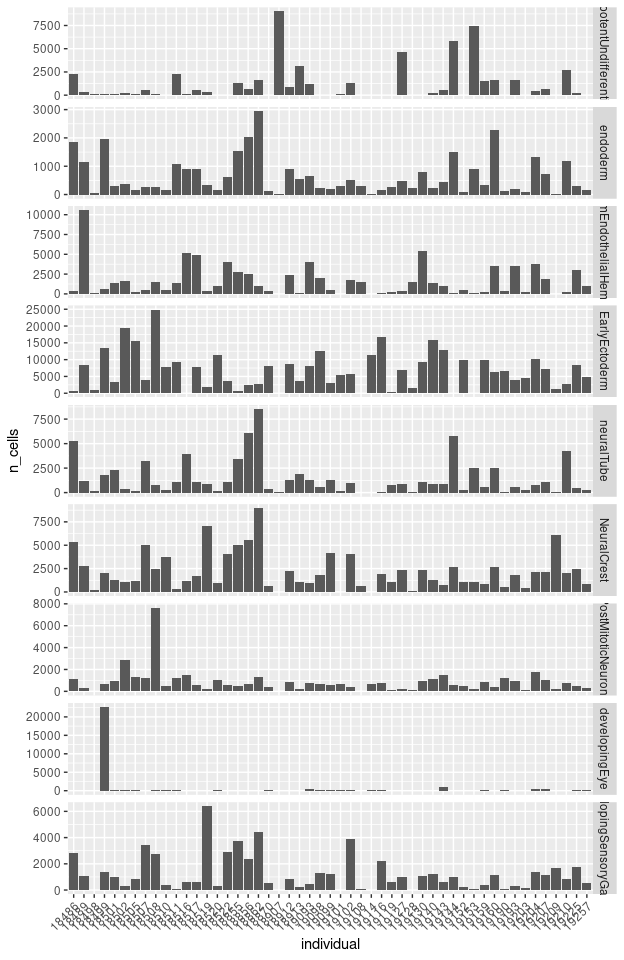

```r
sample_summary %>%
  arrange(n_cells) %>%
  ggplot(aes(x=individual, y=n_cells)) +
  geom_bar(stat="identity") +
  facet_grid(rows=vars(type), scales="free_y") +
  theme(axis.text.x = element_text(angle = 45, hjust=1))
```

How many UMIs? (This tells the same story, nUMI and nCells very highly correlated)

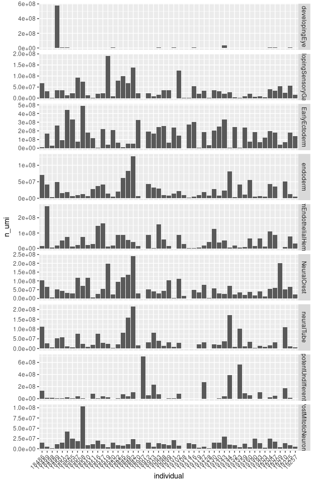

```r
test %>%
  arrange(n_umi) %>%
  ggplot(aes(x=individual, y=n_umi)) +
  geom_bar(stat="identity") +
  facet_grid(rows=vars(type), scales="free_y") +
  theme(axis.text.x = element_text(angle = 45, hjust=1))
```

For each cell type, how many individuals have at least 5 cells? (This is the cutoff for having a pseudobulk sample)

```r
ct_summary <- read_tsv("/project2/gilad/jpopp/ebQTL/data/static/pseudobulk/type/highpass_030222_lowres/samples_per_celltype.tsv") %>%
  mutate(type=factor(type, levels=type_levels))
```

```
indexing samples_per_celltype.tsv [====================================================================] 19.77MB/s, eta:  0s
```

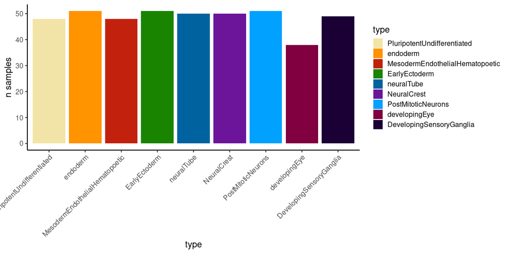

```r
ct_summary  %>%
  ggplot(aes(x=type, y=n, fill=type)) +
  geom_bar(stat="identity") +
  scale_fill_manual(values=type_colors) +
  ylab("n samples") +
  theme_classic(base_size=15) +
  theme(axis.text.x = element_text(angle = 45, hjust=1))
```

## MashR Results

```r
m <- readRDS("/project2/gilad/jpopp/ebQTL/results/mashr/pseudobulk/type/highpass_030222_lowres/eqtls/mashr.tophits.rds")
```

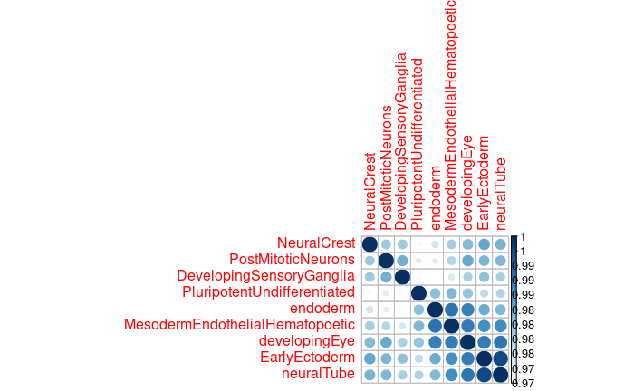

```r
get_pairwise_sharing(m) %>%
  corrplot(is.corr=F, order='hclust', tl.pos='lt')
```

How many eQTLs do we find?

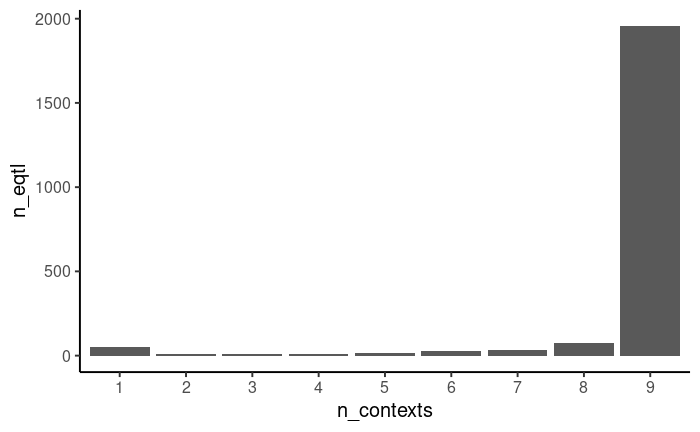

```r
tibble(n_contexts=get_n_significant_conditions(m)) %>%
  filter(n_contexts >= 1) %>%
  dplyr::count(n_contexts, name="n_eqtl") %>%
  mutate(n_contexts=factor(n_contexts, levels=seq(1, 9))) %>%
  ggplot(aes(x=n_contexts, y=n_eqtl)) +
  geom_bar(stat="identity") +
  theme_classic(base_size=15)
```

Now, of the eQTLs that are specific to one context, which context is it?

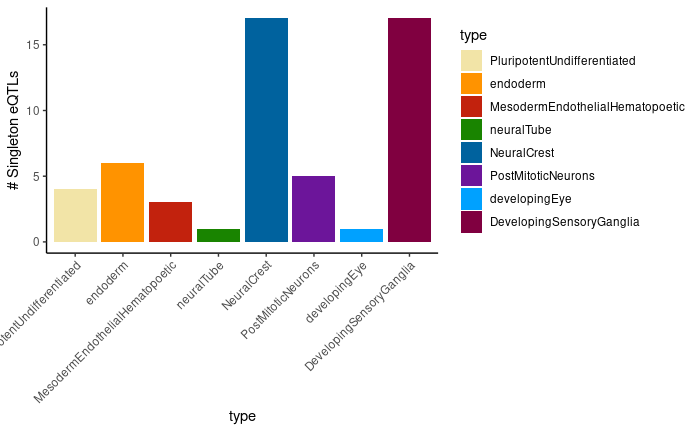

```r
m$result$lfsr %>%
  as_tibble(rownames="gv") %>%
  pivot_longer(-gv, names_to="type", values_to="lfsr") %>%
  filter(lfsr<=0.05) %>%
  group_by(gv) %>%
  select(-lfsr) %>%
  nest() %>%
  mutate(n_contexts=sapply(data, nrow)) %>%
  filter(n_contexts==1) %>%
  unnest(data) %>%
  mutate(type=factor(type, levels=type_levels)) %>%
  group_by(type) %>%
  dplyr::count() %>%
  ggplot(aes(x=type, y=n, fill=type)) +
  geom_bar(stat="identity") +
  theme_classic() +
  ylab("# Singleton eQTLs") +
  theme(axis.text.x = element_text(angle = 45, hjust=1)) +
  scale_fill_manual(values=type_colors)
```

### What are the strongest patterns?

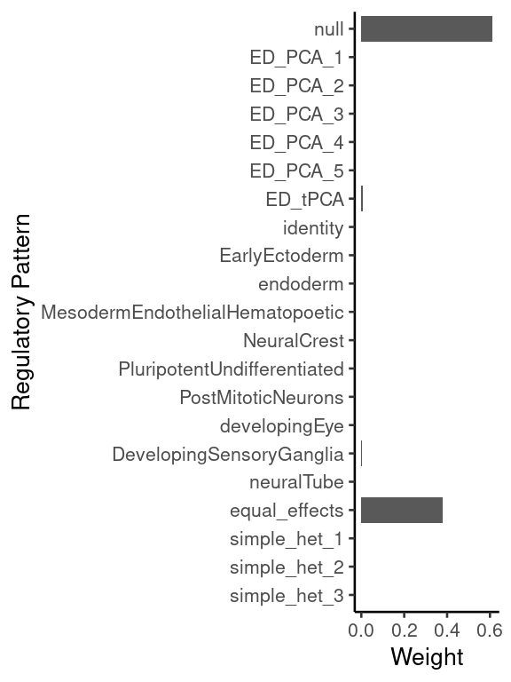

```r
as_tibble(get_estimated_pi(m), rownames="component") %>%
  mutate(component=factor(component, levels=names(get_estimated_pi(m)))) %>%
  ggplot(aes(x=component, y=value)) +
  geom_bar(stat="identity") +
  scale_x_discrete(limits=rev) +
  xlab("Regulatory Pattern") +
  ylab("Weight") +
  coord_flip() +
  theme_classic(base_size = 20)
```

```r
  #theme(axis.text.x = element_text(angle = 45, hjust=1))
```

Show boilerplate covariance matrices

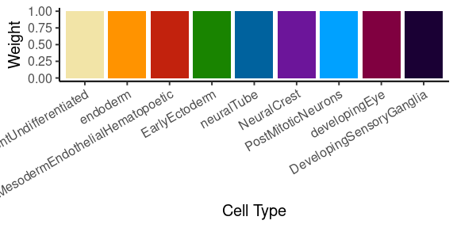

```r
tibble(type=factor(type_levels, levels=type_levels), value=1) %>%
  ggplot(aes(x=type, y=value, fill=type)) +
  geom_bar(stat="identity") +
  scale_fill_manual(values=type_colors) +
  theme_classic(base_size=15) +
  theme(axis.text.x = element_text(angle=30, hjust=1), legend.position="none") +
  xlab("Cell Type") + ylab("Weight")
```

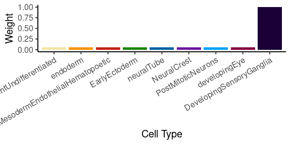

```r
tibble(type=factor(type_levels, levels=type_levels), value=c(0.05, 0.05, 0.05, 0.05, 0.05, 0.05, 0.05, 0.05, 1)) %>%
  ggplot(aes(x=type, y=value, fill=type)) +
  geom_bar(stat="identity") +
  scale_fill_manual(values=type_colors) +
  theme_classic(base_size=15) +
  theme(axis.text.x = element_text(angle=30, hjust=1), legend.position="none") +
  xlab("Cell Type") + ylab("Weight")
```

Show more interesting covariance matrices

[figure not shown]

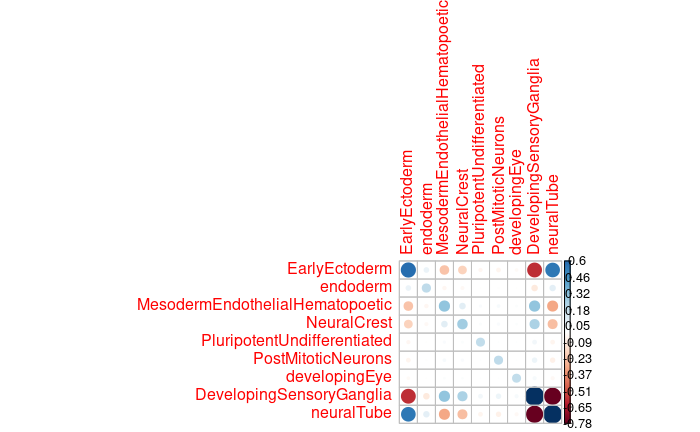

```r
m$fitted_g$Ulist$ED_PCA_5 %>%
  corrplot(is.corr=F)
```

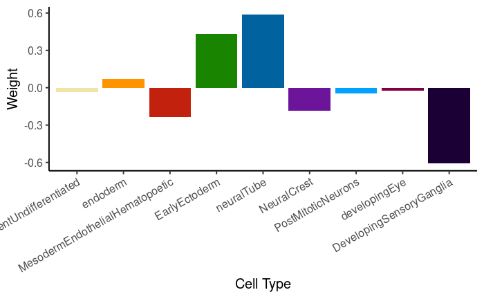

```r
m$fitted_g$Ulist$ED_PCA_5 %>%
  princomp %>%
  .$loadings %>%
  .[,1] %>%
  as_tibble(rownames="type") %>%
  mutate(type=factor(type, levels=type_levels)) %>%
  ggplot(aes(x=type, y=value, fill=type)) +
  geom_bar(stat="identity") +
  scale_fill_manual(values=type_colors) +
  theme_classic(base_size=15) +
  theme(axis.text.x = element_text(angle=30, hjust=1), legend.position="none") +
  xlab("Cell Type") + ylab("Weight")
```

```r
tests <- rownames(get_lfsr(m))
sighits <- get_significant_results(m)
ed1 <- as_tibble(m$posterior_weights) %>%
  rowid_to_column() %>%
  filter(rowid %in% sighits) %>%
  pivot_longer(-rowid, names_to="component", values_to="weight") %>%
  group_by(rowid) %>%
  slice_max(weight) %>%
  filter(component=="ED_tPCA.29") %>%
  pull(rowid)
mash_plot_meta(m, ed1[1], colors=meta.colors(box=type_colors))
```

[output not shown]

## What's going wrong?

There's clearly something off about developing eye, likely having to do with the crazy discrepancy in the number of cells per donor. Let's take a look at the eQTL summary statistics from that cell type. Do they look similar to another cell type (let's say, post mitotic neurons)

```r
eye_qtl <- vroom("/project2/gilad/jpopp/ebQTL/results/mashr/pseudobulk/type/highpass_030222_lowres/eqtls/developingEye/eqtls.mtc.tsv") %>%
  unite(gv, SNP, gene, sep="--") %>%
  mutate(type="eye")
```

```
indexing eqtls.mtc.tsv [=------------------------------------------------------------------------------------------------------------] 152.32GB/s, eta:  0s
indexing eqtls.mtc.tsv [===============================================================================================================] 1.28GB/s, eta:  0s
```

```r
neur_qtl <- vroom("/project2/gilad/jpopp/ebQTL/results/mashr/pseudobulk/type/highpass_030222_lowres/eqtls/PostMitoticNeurons/eqtls.mtc.tsv") %>%
  unite(gv, SNP, gene, sep="--") %>%
  mutate(type="neuron")
```

```
indexing eqtls.mtc.tsv [=------------------------------------------------------------------------------------------------------------] 133.38GB/s, eta:  0s
indexing eqtls.mtc.tsv [===============================================================================================================] 1.22GB/s, eta:  0s
```

```r
qtl_combined <- bind_rows(eye_qtl, neur_qtl)
```

```r
eye_qtl_tophits <- vroom("/project2/gilad/jpopp/ebQTL/results/mashr/pseudobulk/type/highpass_030222_lowres/eqtls/developingEye/eqtls.tophits.tsv") %>%
  unite(gv, SNP, gene, sep="--") %>%
  mutate(type="eye")
```

```
indexing eqtls.tophits.tsv [=========================================================================================================] 145.45GB/s, eta:  0s
```

```r
neur_qtl_tophits <- vroom("/project2/gilad/jpopp/ebQTL/results/mashr/pseudobulk/type/highpass_030222_lowres/eqtls/PostMitoticNeurons/eqtls.tophits.tsv") %>%
  unite(gv, SNP, gene, sep="--") %>%
  mutate(type="neuron")
```

```
indexing eqtls.tophits.tsv [=========================================================================================================] 124.73GB/s, eta:  0s
```

```r
tophits_combined <- bind_rows(eye_qtl_tophits, neur_qtl_tophits)
```

First, a broad look at the distribution of effect sizes and t-statistics for these data

[output not shown]

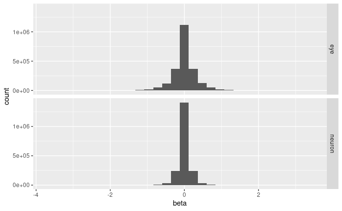

```r
ggplot(qtl_combined, aes(x=beta)) +
  geom_histogram(nbins=30) +
  facet_grid(rows=vars(type))
```

```
Ignoring unknown parameters: nbins
```

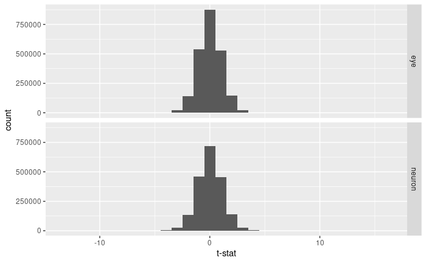

```r
ggplot(qtl_combined, aes(x=`t-stat`)) +
  geom_histogram(nbins=30) +
  facet_grid(rows=vars(type))
```

```
Ignoring unknown parameters: nbins
```

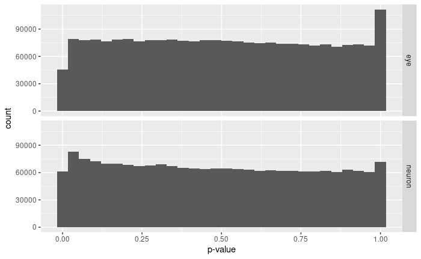

```r
ggplot(qtl_combined, aes(x=`p-value`)) +
  geom_histogram(nbins=100) +
  facet_grid(rows=vars(type))
```

How many significant hits are there in either cell type?

```r
tophits_combined %>%
  filter(q <= 0.05) %>%
  dplyr::count(type)
```

| type | n |
| --- | --- |
| eye | 5 |
| neuron | 105 |

How much agreement is there between the effect size measurements in the two cell types?

```r
double.tested <- qtl_combined %>%
  dplyr::count(gv) %>%
  filter(n==2) %>%
  pull(gv)
```

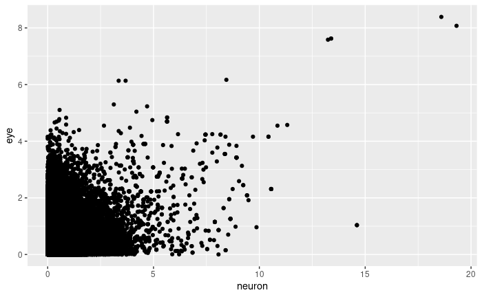

```r
p.comp <- qtl_combined %>%
  filter(gv %in% double.tested) %>%
  mutate(logp=-log10(`p-value`)) %>%
  pivot_wider(id_cols=gv, names_from=type, values_from=logp) %>%
  sample_frac(0.1)
ggplot(p.comp, aes(x=neuron, y=eye)) +
  geom_point()
```

How does this compare to another pair of contexts?

```r
endo_qtl <- vroom("/project2/gilad/jpopp/ebQTL/results/mashr/pseudobulk/type/highpass_030222_lowres/eqtls/endoderm/eqtls.mtc.tsv") %>%
  unite(gv, SNP, gene, sep="--") %>%
  mutate(type="endo")
```

[output not shown]

[output cut: 85 more lines]

```r
meso_qtl <- vroom("/project2/gilad/jpopp/ebQTL/results/mashr/pseudobulk/type/highpass_030222_lowres/eqtls/MesodermEndothelialHematopoetic/eqtls.mtc.tsv") %>%
  unite(gv, SNP, gene, sep="--") %>%
  mutate(type="meso")
```

[output not shown]

[output cut: 77 more lines]

```r
mesendo_combined <- bind_rows(endo_qtl, meso_qtl)
```

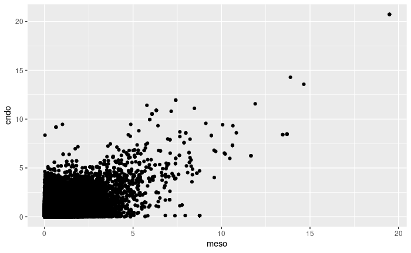

```r
double.tested2 <- mesendo_combined %>%
  dplyr::count(gv) %>%
  filter(n==2) %>%
  pull(gv)
mesendo.comp <- mesendo_combined %>%
  filter(gv %in% double.tested2) %>%
  mutate(logp=-log10(`p-value`)) %>%
  pivot_wider(id_cols=gv, names_from=type, values_from=logp) %>%
  sample_frac(0.1)
ggplot(mesendo.comp, aes(x=meso, y=endo)) +
  geom_point()
```

This is greater agreement than in the others, but there isn't a *huge* difference here, so I think `mashr` might have something to do with the problem.

How would our data-driven covariance matrices differ if we didn't just use the top hits per gene, and instead used a random hit per gene? First, for each cell type how many options would we have if we used a Bonferroni cutoff of 0.25

```r
opts <- eye_qtl %>%
  filter(bonf.p <= 0.25) %>%
  separate(gv, into=c("snp", "gene"), sep="--") %>%
  pull(gene) %>%
  table() %>% table()
opts
```

```
.
  1   2   3   4   5   6   7   8   9  10  11  12  13  14  15  16  17  18  19  20  22  23  24  25  26  27  28  29  30  31  34  35  36  38  39  40  41  43
575 228 116  81  55  46  33  29  30  41  10  13  18  13  10   9   9   4   6   7   4   3   2   5   1   4   2   2   2   3   2   1   3   3   1   1   2   1
 45  46  48  54  59  76  78  86  91  93  94  97 127 151
  1   1   1   2   2   1   1   1   1   1   1   1   1   1
```

```r
sum(opts)
```

```
[1] 1391
```

This actually may be fine, we don't need all genes to be represented for all of our data-driven covariance matrices.